# Session_3-AnalysingData

# 1 Loading packages

```r
## Use the code below to check if you have all required packages installed. If some are not installed already, the code below will install these. If you have all packages installed, then you could load them with the second code.
requiredPackages = c('tidyverse', 'ordinal', 'broom', 'emmeans', 'knitr', 'Hmisc', 'corrplot', 'psycho', 'PresenceAbsence', 'lme4', 'lmerTest')
for(p in requiredPackages){
  if(!require(p,character.only = TRUE)) install.packages(p)
  library(p,character.only = TRUE)
}
```

In this session, we will look at basic functions in R that will help us in running some inferential statistics. These will help us to evaluate the relationship between one (or more) predictor(s) (independent variable) and an outcome (dependent variable).

It is important to know the class of the outcome before doing any pre-data analyses or inferential statistics. Outcome classes can be one of:

1. `Numeric`: As an example, we have length/width of leaf; height of mountain; fundamental frequency of the voice; etc. These are `true` numbers and we can use summaries, t-tests, linear models, etc.
2. `Categorical` (Unordered): Observations for two or more categories. As an example, we can have gender of a speaker (male or female); responses to a True vs False perception tests; Colour (unordered) categorisation, e.g., red, blue, yellow, orange, etc.. For these we can use a Generalised Linear Model (binomial or multinomial) or a simple chi-square test. Count data are numbers related to a category. But these should be analysed using a poisson logistic regression
3. `Categorical` (Ordered): When you run a rating experiment, where the outcome is either `numeric` (i.e., 1, 2, 3, 4, 5) or `categories` (i.e., disagree, neutral, agree). The `numeric` option is NOT a true number as for the participant, these are categories. Cumulative Logit models (or Generalised Linear Model with a cumulative function) are used. The mean is meaningless here, and the median is a preferred descriptive statistic.

The content will be split into 5 sections. Some of you will only ever look at some of these, while others may need to use all. Look at the section that works best for your data.

1. Pre-data analyses: We will look at summaries, plotting, correlations, checking normality of distribution and homogeneity of variance (for t-tests)
2. Statistical Analyses: from t-test and ANOVA, to Linear Models: model estimation, understanding coefficients, residuals, and predictions
3. We then move to Generalised Linear Models, with Logistic Regression (with a binomial categorical outcome) and touch upon Signal Detection Theory for estimating accuracy, biases, with sensitivity and specificity measures.
4. Dealing with rating data using Generalised Linear Models, with a Cumulative Logit function
5. Linear Mixed effects Models: Introduction to random effects and how to deal with these.

# 2 Pre-data analsyes

## 2.1 Built-in datasets

We will use one of the built in `R`. You can check all available datasets in `R` using the following:

```r
data()
# or below for all datasets available in all installed packages
data(package = .packages(all.available = TRUE))
```

We will use the `iris` dataset from the package `MASS`

## 2.2 Checking structure and summaries

### 2.2.1 Structure

```r
iris %>%
  str()
```

```
'data.frame':   150 obs. of  5 variables:
 $ Sepal.Length: num  5.1 4.9 4.7 4.6 5 5.4 4.6 5 4.4 4.9 ...
 $ Sepal.Width : num  3.5 3 3.2 3.1 3.6 3.9 3.4 3.4 2.9 3.1 ...
 $ Petal.Length: num  1.4 1.4 1.3 1.5 1.4 1.7 1.4 1.5 1.4 1.5 ...
 $ Petal.Width : num  0.2 0.2 0.2 0.2 0.2 0.4 0.3 0.2 0.2 0.1 ...
 $ Species     : Factor w/ 3 levels "setosa","versicolor",..: 1 1 1 1 1 1 1 1 1 1 ...
```

We have a dataframe with 150 observations and 5 variables; 4 numeric and 1 factor with 3 levels.

### 2.2.2 Summary

We summarise the data to see the trends:

```r
iris %>%
  summary()
```

```
  Sepal.Length    Sepal.Width     Petal.Length    Petal.Width          Species
 Min.   :4.300   Min.   :2.000   Min.   :1.000   Min.   :0.100   setosa    :50
 1st Qu.:5.100   1st Qu.:2.800   1st Qu.:1.600   1st Qu.:0.300   versicolor:50
 Median :5.800   Median :3.000   Median :4.350   Median :1.300   virginica :50
 Mean   :5.843   Mean   :3.057   Mean   :3.758   Mean   :1.199
 3rd Qu.:6.400   3rd Qu.:3.300   3rd Qu.:5.100   3rd Qu.:1.800
 Max.   :7.900   Max.   :4.400   Max.   :6.900   Max.   :2.500
```

So we have an equal dataframe (50 observations under each level of the factor `Species`), with no missing values (aka `NA`).

### 2.2.3 Advanced

#### 2.2.3.1 For a specific variable

What if you want to summarise the data and get the mean, SD, by each level of the factor for `Sepal.Length`?

```r
iris %>%
  group_by(Species) %>%
  summarise(
  SL.Mean = mean(Sepal.Length),
  SL.SD = sd(Sepal.Length)
  )
```

| Species | SL.Mean | SL.SD |
| --- | --- | --- |
| setosa | 5.006 | 0.3524897 |
| versicolor | 5.936 | 0.5161711 |
| virginica | 6.588 | 0.6358796 |

#### 2.2.3.2 For all variables

```r
iris %>%
  group_by(Species) %>%
  summarise_all(list(mean = mean, sd = sd)
  )
```

| Species | Sepal.Length_mean | Sepal.Width_mean | Petal.Length_mean | Petal.Width_mean | Sepal.Length_sd | Sepal.Width_sd | Petal.Length_sd | Petal.Width_sd |
| --- | --- | --- | --- | --- | --- | --- | --- | --- |
| setosa | 5.006 | 3.428 | 1.462 | 0.246 | 0.3524897 | 0.3790644 | 0.1736640 | 0.1053856 |
| versicolor | 5.936 | 2.770 | 4.260 | 1.326 | 0.5161711 | 0.3137983 | 0.4699110 | 0.1977527 |
| virginica | 6.588 | 2.974 | 5.552 | 2.026 | 0.6358796 | 0.3224966 | 0.5518947 | 0.2746501 |

### 2.2.4 Up to you

Do some additional summaries.. You may want to check the `median`, `range`, etc..

## 2.3 Plot

We can make a boxplot of the data and add a trend line. This allows us to visualise the median, and quantiles in addition to the standard deviation and any outliers… All in the same plot!

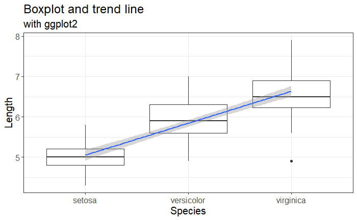

```r
iris %>%
  ggplot(aes(x = Species, y = Sepal.Length)) +
  geom_boxplot() +
  geom_smooth(aes(x = as.numeric(Species), y = Sepal.Length), method = "lm") +
  labs(x = "Species", y = "Length", title = "Boxplot and trend line", subtitle = "with ggplot2") +
  theme_bw() + theme(text = element_text(size = 15))
```

Here I have used the variable `Sepal.Length`. You can use any of the additional variables to plot the data.

## 2.4 Correlation tests

### 2.4.1 Basic correlations

We use the function `cor` to obtain the pearson correlation and `cor.test` to run a basic correlation test on our data with significance testing

```r
cor(iris$Sepal.Length, iris$Petal.Length, method = "pearson")
```

```
[1] 0.8717538
```

```r
cor.test(iris$Sepal.Length, iris$Petal.Length)
```

```
    Pearson's product-moment correlation

data:  iris$Sepal.Length and iris$Petal.Length
t = 21.646, df = 148, p-value < 2.2e-16
alternative hypothesis: true correlation is not equal to 0
95 percent confidence interval:
 0.8270363 0.9055080
sample estimates:
      cor
0.8717538
```

#### 2.4.1.1 Up to you

Can you check whether there is a correlation between the `Sepal.Length` and the `Petal.Width`? What about `Petal.Length` and `Petal.Width`?

### 2.4.2 Using the package `corrplot`

Above, we did a correlation test on two predictors. We run multiple correlations on multiple predictors.

#### 2.4.2.1 Correlations

```r
## correlation using "corrplot"
## based on the function `rcorr' from the `Hmisc` package
## Need to change dataframe into a matrix
corr <- as.matrix(iris[-5]) %>%
  rcorr(type="pearson")
print(corr)
```

```
             Sepal.Length Sepal.Width Petal.Length Petal.Width
Sepal.Length         1.00       -0.12         0.87        0.82
Sepal.Width         -0.12        1.00        -0.43       -0.37
Petal.Length         0.87       -0.43         1.00        0.96
Petal.Width          0.82       -0.37         0.96        1.00

n= 150


P
             Sepal.Length Sepal.Width Petal.Length Petal.Width
Sepal.Length              0.1519      0.0000       0.0000
Sepal.Width  0.1519                   0.0000       0.0000
Petal.Length 0.0000       0.0000                   0.0000
Petal.Width  0.0000       0.0000      0.0000
```

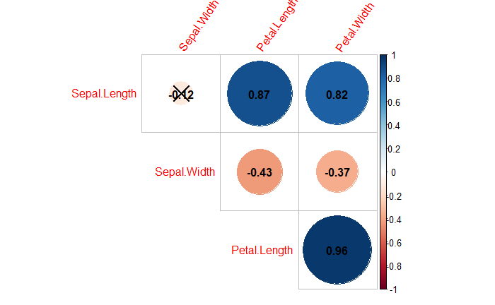

```r
corrplot(corr$r, p.mat = corr$P,
         addCoef.col = "black", diag = FALSE, type = "upper", tl.srt = 55)
```

#### 2.4.2.2 Up to you

Look into the `corrplot` specification, using `?corrplot` and amend some of the criteria. Run a correlation plot while filtering the data according to the `species`.

```r
# hint
# create a new dataframe by filtering `Species`, then compute correlations and plot
```

Up to now, we have done some basic summaries and checked the correlations in the data. The pearson correlations we have done provided us with significance levels related to the correlations between two *numeric* outcomes. We continue by examining the normality of distribution of our data.

## 2.5 Normality of distribution

### 2.5.1 Subsetting data

In the `iris` dataset, we have a categorical predictor: `Species` which has three levels

```r
levels(iris$Species)
```

```
[1] "setosa"     "versicolor" "virginica"
```

Let’s subset the data to `setosa` and `versicolor`. We will also check the normality and homogeneity of variance in the data

```r
irisSub <- iris %>%
  filter(Species %in% c("setosa", "versicolor"))
```

### 2.5.2 Shapiro test

To check normality of distribution, we use the `shapiro.test` on the numeric outcome. Given that our predictor now has two levels. We need to subset the data again to check normality of the outcome `Sepal.Length` for each level of our factor `Species`

```r
irisSubSet <- iris %>%
  filter(Species == "setosa")
irisSubVers <- iris %>%
  filter(Species == "versicolor")

shapiro.test(irisSubSet$Sepal.Length)
```

```
    Shapiro-Wilk normality test

data:  irisSubSet$Sepal.Length
W = 0.9777, p-value = 0.4595
```

```r
shapiro.test(irisSubVers$Sepal.Length)
```

```
    Shapiro-Wilk normality test

data:  irisSubVers$Sepal.Length
W = 0.97784, p-value = 0.4647
```

How to interpret this non-statistically significant result? This tells us that the distribution of the data is not statistically different from a normal distribution.

### 2.5.3 Density plot

We can also use a density plot to evaluate normality. The results show that both levels have bell shaped distributions.

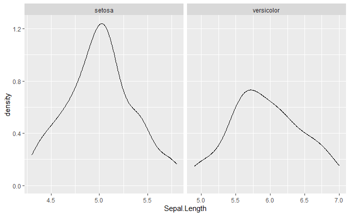

```r
irisSub %>%
  ggplot(aes(x = Sepal.Length))+
  geom_density()+
  facet_wrap(~Species, scales = "free_x")
```

### 2.5.4 Homogeneity of variance

Because our data is normally distributed, we can use the `bartlett` test. If our data were non-normally distributed, we would use the Levene Test (either with `var.test` from base-R or `leveneTest` from the car package We can check both.

#### 2.5.4.1 Bartlett test

```r
irisSub %>%
  bartlett.test(Sepal.Length ~ Species, data = .)
```

```
    Bartlett test of homogeneity of variances

data:  Sepal.Length by Species
Bartlett's K-squared = 6.8917, df = 1, p-value = 0.00866
```

#### 2.5.4.2 Levene test

```r
irisSub %>%
  var.test(Sepal.Length ~ Species, data = .)
```

```
    F test to compare two variances

data:  Sepal.Length by Species
F = 0.46634, num df = 49, denom df = 49, p-value = 0.008657
alternative hypothesis: true ratio of variances is not equal to 1
95 percent confidence interval:
 0.2646385 0.8217841
sample estimates:
ratio of variances
         0.4663429
```

```r
irisSub %>%
  car::leveneTest(Sepal.Length ~ Species, data = .)
```

```
Levene's Test for Homogeneity of Variance (center = median)
      Df F value   Pr(>F)
group  1  8.1727 0.005196 **
      98
---
Signif. codes:  0 ‘***’ 0.001 ‘**’ 0.01 ‘*’ 0.05 ‘.’ 0.1 ‘ ’ 1
```

In all cases, the statistically significant result indicates that there is evidence that the variance of two levels of the factor `Species` is statistically significant; i.e., the variances are not equal. This is important as we will use this in our t-test later on

# 3 Linear Models

Up to now, we have looked at descriptive statistics, and evaluated summaries, correlations in the data (with p values), and checked the normality of distribution of our data.

We are now interested in looking at group differences.

Let us start with a simple t-test

## 3.1 First steps

### 3.1.1 T-test

```r
irisSub %>%
  t.test(Sepal.Length ~ Species, data = ., var.equal = FALSE)
```

```
    Welch Two Sample t-test

data:  Sepal.Length by Species
t = -10.521, df = 86.538, p-value < 2.2e-16
alternative hypothesis: true difference in means is not equal to 0
95 percent confidence interval:
 -1.1057074 -0.7542926
sample estimates:
    mean in group setosa mean in group versicolor
                   5.006                    5.936
```

To interpret the t-test, we say that there is evidence for a statistically significant difference between the two groups: `setosa` and `versicolor`: `t(86) = -10.521, p < 2.2e-16`. The mean of `setosa` is significantly lower than that of `versicolor`.

### 3.1.2 Linear Model

Let us run a linear model on the same data

```r
irisSub %>%
  lm(Sepal.Length ~ Species, data = .) %>%
  summary()
```

```
Call:
lm(formula = Sepal.Length ~ Species, data = .)

Residuals:
    Min      1Q  Median      3Q     Max
-1.0360 -0.3135 -0.0060  0.2715  1.0640

Coefficients:
                  Estimate Std. Error t value Pr(>|t|)
(Intercept)        5.00600    0.06250   80.09   <2e-16 ***
Speciesversicolor  0.93000    0.08839   10.52   <2e-16 ***
---
Signif. codes:  0 ‘***’ 0.001 ‘**’ 0.01 ‘*’ 0.05 ‘.’ 0.1 ‘ ’ 1

Residual standard error: 0.442 on 98 degrees of freedom
Multiple R-squared:  0.5304,    Adjusted R-squared:  0.5256
F-statistic: 110.7 on 1 and 98 DF,  p-value: < 2.2e-16
```

Any comments? discuss with your neighbour.

The results of the linear model are exactly the same, albeit with a difference in the sign of the difference. This indicates that the $\beta$ coefficient for `versicolor` is significantly higher than that of `setosa` by `0.93000`: `t(98) = 10.52, p < <2e-16`.

The dataset `iris` contains three species. We will run an ANOVA and a linear model on the data.

### 3.1.3 Basic ANOVA

We can use the function `aov` to run an Analysis of Variance on the full dataset

```r
iris %>%
  aov(Sepal.Length ~ Species, data = .) %>%
  summary()
```

```
             Df Sum Sq Mean Sq F value Pr(>F)
Species       2  63.21  31.606   119.3 <2e-16 ***
Residuals   147  38.96   0.265
---
Signif. codes:  0 ‘***’ 0.001 ‘**’ 0.01 ‘*’ 0.05 ‘.’ 0.1 ‘ ’ 1
```

### 3.1.4 Linear model

We can use the function `lm` to run a linear model

```r
iris %>%
  lm(Sepal.Length ~ Species, data = .) %>%
  summary()
```

```
Call:
lm(formula = Sepal.Length ~ Species, data = .)

Residuals:
    Min      1Q  Median      3Q     Max
-1.6880 -0.3285 -0.0060  0.3120  1.3120

Coefficients:
                  Estimate Std. Error t value Pr(>|t|)
(Intercept)         5.0060     0.0728  68.762  < 2e-16 ***
Speciesversicolor   0.9300     0.1030   9.033 8.77e-16 ***
Speciesvirginica    1.5820     0.1030  15.366  < 2e-16 ***
---
Signif. codes:  0 ‘***’ 0.001 ‘**’ 0.01 ‘*’ 0.05 ‘.’ 0.1 ‘ ’ 1

Residual standard error: 0.5148 on 147 degrees of freedom
Multiple R-squared:  0.6187,    Adjusted R-squared:  0.6135
F-statistic: 119.3 on 2 and 147 DF,  p-value: < 2.2e-16
```

But wait… How is the linear model comparable to the analysis of variance we ran above? This linear model derives the analysis of variance we saw above, use `anova` on your linear model..

Here are the results of the initial Analysis of variance:

```r
iris %>%
  aov(Sepal.Length ~ Species, data = .) %>%
  summary()
```

```
             Df Sum Sq Mean Sq F value Pr(>F)
Species       2  63.21  31.606   119.3 <2e-16 ***
Residuals   147  38.96   0.265
---
Signif. codes:  0 ‘***’ 0.001 ‘**’ 0.01 ‘*’ 0.05 ‘.’ 0.1 ‘ ’ 1
```

And here are the results of the linear model with the `anova` function

```r
iris %>%
  lm(Sepal.Length ~ Species, data = .) %>%
  anova()
```

```
Analysis of Variance Table

Response: Sepal.Length
           Df Sum Sq Mean Sq F value    Pr(>F)
Species     2 63.212  31.606  119.26 < 2.2e-16 ***
Residuals 147 38.956   0.265
---
Signif. codes:  0 ‘***’ 0.001 ‘**’ 0.01 ‘*’ 0.05 ‘.’ 0.1 ‘ ’ 1
```

They are exactly the same… The underlying of an Analysis of variance is a linear model. We will continue with a linear model to understand it better

## 3.2 Linear Model

The basic assumption of a Linear model is to create a regression analysis on the data. We have an outcome (or dependent variable) and a predictor (or an independent variable). The formula of a linear model is as follows `outcome ~ predictor` that can be read as “outcome as a function of the predictor”. We can add “1” to specify an intercept, but this is by default added to the model

### 3.2.1 Model estimation

```r
mdl.lm <- iris %>%
  lm(Sepal.Length ~ Species, data = .)
# same as below.
#mdl.lm <- lm(Sepal.Length ~ 1 + Species, data = iris)
mdl.lm #also print(mdl.lm)
```

```
Call:
lm(formula = Sepal.Length ~ Species, data = .)

Coefficients:
      (Intercept)  Speciesversicolor   Speciesvirginica
            5.006              0.930              1.582
```

```r
summary(mdl.lm)
```

```
Call:
lm(formula = Sepal.Length ~ Species, data = .)

Residuals:
    Min      1Q  Median      3Q     Max
-1.6880 -0.3285 -0.0060  0.3120  1.3120

Coefficients:
                  Estimate Std. Error t value Pr(>|t|)
(Intercept)         5.0060     0.0728  68.762  < 2e-16 ***
Speciesversicolor   0.9300     0.1030   9.033 8.77e-16 ***
Speciesvirginica    1.5820     0.1030  15.366  < 2e-16 ***
---
Signif. codes:  0 ‘***’ 0.001 ‘**’ 0.01 ‘*’ 0.05 ‘.’ 0.1 ‘ ’ 1

Residual standard error: 0.5148 on 147 degrees of freedom
Multiple R-squared:  0.6187,    Adjusted R-squared:  0.6135
F-statistic: 119.3 on 2 and 147 DF,  p-value: < 2.2e-16
```

### 3.2.2 Tidying the output

```r
# from library(broom)
tidy(mdl.lm) %>%
  select(term, estimate) %>%
  mutate(estimate = round(estimate, 3))
```

| term | estimate |
| --- | --- |
| (Intercept) | 5.006 |
| Speciesversicolor | 0.930 |
| Speciesvirginica | 1.582 |

```r
mycoefE <- tidy(mdl.lm) %>% pull(estimate)
```

### 3.2.3 Obtaining our “true” coefficients

But where are our actual values based on the means in the table above?

We run a model that suppresses the intercept (i.e., adding 0 instead of 1) and this will allow us to obtain the “true” coefficients for each level of our predictor. This is also known as a `saturated` model

```r
mdl.lm.2 <- iris %>%
  lm(Sepal.Length ~ 0 + Species, data = .)
summary(mdl.lm.2)
```

```
Call:
lm(formula = Sepal.Length ~ 0 + Species, data = .)

Residuals:
    Min      1Q  Median      3Q     Max
-1.6880 -0.3285 -0.0060  0.3120  1.3120

Coefficients:
                  Estimate Std. Error t value Pr(>|t|)
Speciessetosa       5.0060     0.0728   68.76   <2e-16 ***
Speciesversicolor   5.9360     0.0728   81.54   <2e-16 ***
Speciesvirginica    6.5880     0.0728   90.49   <2e-16 ***
---
Signif. codes:  0 ‘***’ 0.001 ‘**’ 0.01 ‘*’ 0.05 ‘.’ 0.1 ‘ ’ 1

Residual standard error: 0.5148 on 147 degrees of freedom
Multiple R-squared:  0.9925,    Adjusted R-squared:  0.9924
F-statistic:  6522 on 3 and 147 DF,  p-value: < 2.2e-16
```

```r
#Setosa
mycoefE[1]
```

```
[1] 5.006
```

```r
#Versicolor
mycoefE[1] + mycoefE[2]
```

```
[1] 5.936
```

```r
#Virginica
mycoefE[1] + mycoefE[3]
```

```
[1] 6.588
```

The same as

```r
tidy(mdl.lm.2) %>%
  select(term, estimate) %>%
  mutate(estimate = round(estimate, 3))
```

| term | estimate |
| --- | --- |
| Speciessetosa | 5.006 |
| Speciesversicolor | 5.936 |
| Speciesvirginica | 6.588 |

```r
mycoefE <- tidy(mdl.lm.2) %>%
  pull(estimate)

#Setosa
mycoefE[1]
```

```
[1] 5.006
```

```r
#Versicolor
mycoefE[2]
```

```
[1] 5.936
```

```r
#Virginica
mycoefE[3]
```

```
[1] 6.588
```

### 3.2.4 Nice table of our model summary

We can also obtain a nice table of our model summary. We can use the package `knitr` or `xtable`

#### 3.2.4.1 Directly from model summary

```r
kable(summary(mdl.lm)$coef, digits = 3)
```

|  | Estimate | Std. Error | t value | Pr(>\|t\|) |
| --- | --- | --- | --- | --- |
| (Intercept) | 5.006 | 0.073 | 68.762 | 0 |
| Speciesversicolor | 0.930 | 0.103 | 9.033 | 0 |
| Speciesvirginica | 1.582 | 0.103 | 15.366 | 0 |

```r
NA
```

#### 3.2.4.2 From the `tidy` output

```r
mdl.lmT <- tidy(mdl.lm)
kable(mdl.lmT, digits = 3)
```

| term | estimate | std.error | statistic | p.value |
| --- | --- | --- | --- | --- |
| (Intercept) | 5.006 | 0.073 | 68.762 | 0 |
| Speciesversicolor | 0.930 | 0.103 | 9.033 | 0 |
| Speciesvirginica | 1.582 | 0.103 | 15.366 | 0 |

### 3.2.5 Dissecting the model

Let us dissect the model. If you use “str”, you will be able to see what is available under our linear model. To access some info from the model

#### 3.2.5.1 “str” and “coef”

```r
str(mdl.lm)
```

```
List of 13
 $ coefficients : Named num [1:3] 5.01 0.93 1.58
  ..- attr(*, "names")= chr [1:3] "(Intercept)" "Speciesversicolor" "Speciesvirginica"
 $ residuals    : Named num [1:150] 0.094 -0.106 -0.306 -0.406 -0.006 ...
  ..- attr(*, "names")= chr [1:150] "1" "2" "3" "4" ...
 $ effects      : Named num [1:150] -71.5659 0.8025 7.91 -0.3826 0.0174 ...
  ..- attr(*, "names")= chr [1:150] "(Intercept)" "Speciesversicolor" "Speciesvirginica" "" ...
 $ rank         : int 3
 $ fitted.values: Named num [1:150] 5.01 5.01 5.01 5.01 5.01 ...
  ..- attr(*, "names")= chr [1:150] "1" "2" "3" "4" ...
 $ assign       : int [1:3] 0 1 1
 $ qr           :List of 5
  ..$ qr   : num [1:150, 1:3] -12.2474 0.0816 0.0816 0.0816 0.0816 ...
  .. ..- attr(*, "dimnames")=List of 2
  .. .. ..$ : chr [1:150] "1" "2" "3" "4" ...
  .. .. ..$ : chr [1:3] "(Intercept)" "Speciesversicolor" "Speciesvirginica"
  .. ..- attr(*, "assign")= int [1:3] 0 1 1
  .. ..- attr(*, "contrasts")=List of 1
  .. .. ..$ Species: chr "contr.treatment"
  ..$ qraux: num [1:3] 1.08 1.05 1.09
  ..$ pivot: int [1:3] 1 2 3
  ..$ tol  : num 1e-07
  ..$ rank : int 3
  ..- attr(*, "class")= chr "qr"
 $ df.residual  : int 147
 $ contrasts    :List of 1
  ..$ Species: chr "contr.treatment"
 $ xlevels      :List of 1
  ..$ Species: chr [1:3] "setosa" "versicolor" "virginica"
 $ call         : language lm(formula = Sepal.Length ~ Species, data = .)
 $ terms        :Classes 'terms', 'formula'  language Sepal.Length ~ Species
  .. ..- attr(*, "variables")= language list(Sepal.Length, Species)
  .. ..- attr(*, "factors")= int [1:2, 1] 0 1
  .. .. ..- attr(*, "dimnames")=List of 2
  .. .. .. ..$ : chr [1:2] "Sepal.Length" "Species"
  .. .. .. ..$ : chr "Species"
  .. ..- attr(*, "term.labels")= chr "Species"
  .. ..- attr(*, "order")= int 1
  .. ..- attr(*, "intercept")= int 1
  .. ..- attr(*, "response")= int 1
  .. ..- attr(*, ".Environment")=<environment: 0x00000267f1c2e870>
  .. ..- attr(*, "predvars")= language list(Sepal.Length, Species)
  .. ..- attr(*, "dataClasses")= Named chr [1:2] "numeric" "factor"
  .. .. ..- attr(*, "names")= chr [1:2] "Sepal.Length" "Species"
 $ model        :'data.frame':  150 obs. of  2 variables:
  ..$ Sepal.Length: num [1:150] 5.1 4.9 4.7 4.6 5 5.4 4.6 5 4.4 4.9 ...
  ..$ Species     : Factor w/ 3 levels "setosa","versicolor",..: 1 1 1 1 1 1 1 1 1 1 ...
  ..- attr(*, "terms")=Classes 'terms', 'formula'  language Sepal.Length ~ Species
  .. .. ..- attr(*, "variables")= language list(Sepal.Length, Species)
  .. .. ..- attr(*, "factors")= int [1:2, 1] 0 1
  .. .. .. ..- attr(*, "dimnames")=List of 2
  .. .. .. .. ..$ : chr [1:2] "Sepal.Length" "Species"
  .. .. .. .. ..$ : chr "Species"
  .. .. ..- attr(*, "term.labels")= chr "Species"
  .. .. ..- attr(*, "order")= int 1
  .. .. ..- attr(*, "intercept")= int 1
  .. .. ..- attr(*, "response")= int 1
  .. .. ..- attr(*, ".Environment")=<environment: 0x00000267f1c2e870>
  .. .. ..- attr(*, "predvars")= language list(Sepal.Length, Species)
  .. .. ..- attr(*, "dataClasses")= Named chr [1:2] "numeric" "factor"
  .. .. .. ..- attr(*, "names")= chr [1:2] "Sepal.Length" "Species"
 - attr(*, "class")= chr "lm"
```

```r
coef(mdl.lm)
```

```
      (Intercept) Speciesversicolor  Speciesvirginica
            5.006             0.930             1.582
```

```r
## same as
## mdl.lm$coefficients
```

#### 3.2.5.2 “coef” and “coefficients”

```r
coef(mdl.lm)[1] # same as mdl.lm$coefficients[1]
```

```
(Intercept)
      5.006
```

```r
coef(mdl.lm)[2] # same as mdl.lm$coefficients[2]
```

```
Speciesversicolor
             0.93
```

```r
summary(mdl.lm)$coefficients[2, ] # full row
```

```
    Estimate   Std. Error      t value     Pr(>|t|)
9.300000e-01 1.029579e-01 9.032819e+00 8.770194e-16
```

```r
summary(mdl.lm)$coefficients[2, 4] #for p value
```

```
[1] 8.770194e-16
```

#### 3.2.5.3 Up to you

Play around with the model summary and obtain the t values for the three levels. You can do this by referring to the coefficient as above

#### 3.2.5.4 Residuals

What about residuals (difference between the observed value and the estimated value of the quantity) and fitted values?

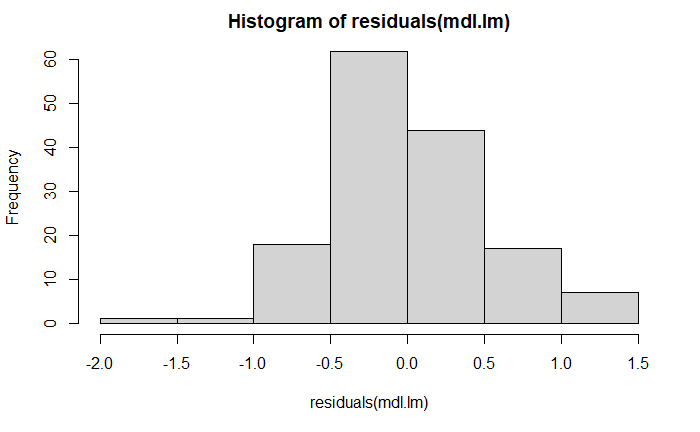

```r
hist(residuals(mdl.lm))
```

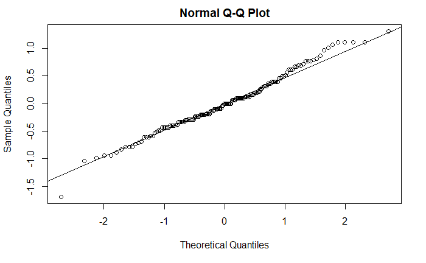

```r
qqnorm(residuals(mdl.lm)); qqline(residuals(mdl.lm))
```

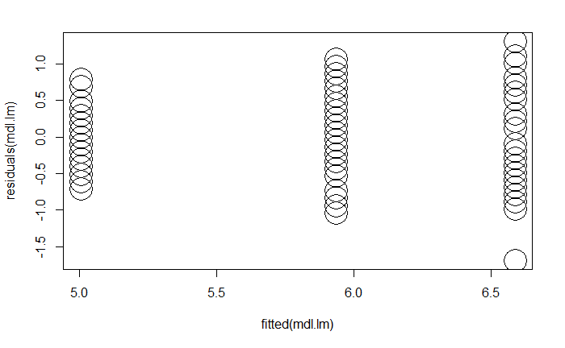

```r
plot(fitted(mdl.lm), residuals(mdl.lm), cex = 4)
```

#### 3.2.5.5 Goodness of fit?

```r
AIC(mdl.lm) # Akaike's Information Criterion, lower values are better
```

```
[1] 231.452
```

```r
BIC(mdl.lm) # Bayesian AIC
```

```
[1] 243.4945
```

```r
logLik(mdl.lm)  # log likelihood
```

```
'log Lik.' -111.726 (df=4)
```

Or use the following from `broom`

```r
glance(mdl.lm)
```

| r.squared | adj.r.squared | sigma | statistic | p.value | df | logLik | AIC | BIC | deviance | df.residual |
| --- | --- | --- | --- | --- | --- | --- | --- | --- | --- | --- |
| 0.6187057 | 0.6135181 | 0.5147894 | 119.2645 | 1.669669e-31 | 3 | -111.726 | 231.452 | 243.4945 | 38.9562 | 147 |

#### 3.2.5.6 Significance testing

Are the above informative? of course not directly. If we want to test for overall significance of model. We run a null model (aka intercept only) and compare models.

```r
mdl.lm.Null <- iris %>%
  lm(Sepal.Length ~ 1, data = .)
mdl.comp <- anova(mdl.lm.Null, mdl.lm)
mdl.comp
```

```
Analysis of Variance Table

Model 1: Sepal.Length ~ 1
Model 2: Sepal.Length ~ Species
  Res.Df     RSS Df Sum of Sq      F    Pr(>F)
1    149 102.168
2    147  38.956  2    63.212 119.26 < 2.2e-16 ***
---
Signif. codes:  0 ‘***’ 0.001 ‘**’ 0.01 ‘*’ 0.05 ‘.’ 0.1 ‘ ’ 1
```

The results show that adding the factor “Species” improves the model fit. We can write this as follows: Model comparison showed that the addition of Species improved the model fit when compared with an intercept only model ($F$(2) = 119.26, *p* < 1.669669210^{-31})

#### 3.2.5.7 Plotting fitted values

##### 3.2.5.7.1 Trend line

Let’s plot our fitted values but only for the trend line

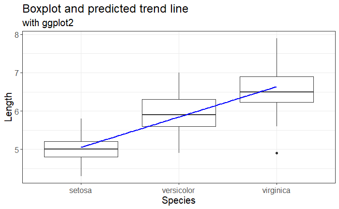

```r
iris %>%
  ggplot(aes(x = Species, y = Sepal.Length))+
  geom_boxplot() +
  labs(x = "Species", y = "Length", title = "Boxplot and predicted trend line", subtitle = "with ggplot2") +
  theme_bw() + theme(text = element_text(size = 15))+
  geom_smooth(aes(x = as.numeric(Species), y = predict(mdl.lm)), method = "lm", color = "blue")
```

This allows us to plot the fitted values from our model with the predicted linear trend. This is exactly the same as our original data.

##### 3.2.5.7.2 Predicted means and the trend line

We can also plot the predicted means and linear trend

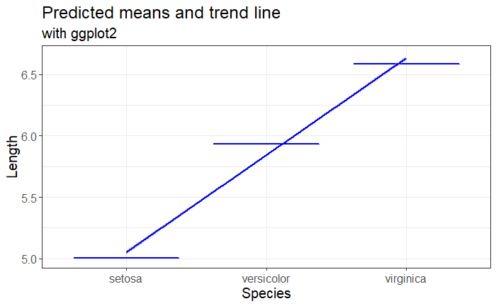

```r
iris %>%
  ggplot(aes(x = Species, y = predict(mdl.lm)))+
  geom_boxplot(color = "blue") +
  labs(x = "Species", y = "Length", title = "Predicted means and trend line", subtitle = "with ggplot2") +
  theme_bw() + theme(text = element_text(size = 15))+
  geom_smooth(aes(x = as.numeric(Species), y = predict(mdl.lm)), method = "lm", color = "blue")
```

##### 3.2.5.7.3 Raw data, predicted means and the trend line

We can also plot the actual data, the predicted means and linear trend

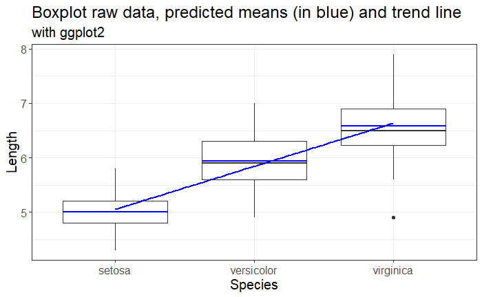

```r
iris %>%
  ggplot(aes(x = Species, y = Sepal.Length))+
  geom_boxplot()+
  geom_boxplot(aes(x = Species, y = predict(mdl.lm)), color = "blue") +
  labs(x = "Species", y = "Length", title = "Boxplot raw data, predicted means (in blue) and trend line", subtitle = "with ggplot2") +
  theme_bw() + theme(text = element_text(size = 15))+
  geom_smooth(aes(x = as.numeric(Species), y = predict(mdl.lm)), method = "lm", color = "blue")
```

### 3.2.6 What about pairwise comparison?

Based on our model’s summary, can you tell me if there is a difference between Versicolor and Virginica?

```r
summary(mdl.lm)
```

```
Call:
lm(formula = Sepal.Length ~ Species, data = .)

Residuals:
    Min      1Q  Median      3Q     Max
-1.6880 -0.3285 -0.0060  0.3120  1.3120

Coefficients:
                  Estimate Std. Error t value Pr(>|t|)
(Intercept)         5.0060     0.0728  68.762  < 2e-16 ***
Speciesversicolor   0.9300     0.1030   9.033 8.77e-16 ***
Speciesvirginica    1.5820     0.1030  15.366  < 2e-16 ***
---
Signif. codes:  0 ‘***’ 0.001 ‘**’ 0.01 ‘*’ 0.05 ‘.’ 0.1 ‘ ’ 1

Residual standard error: 0.5148 on 147 degrees of freedom
Multiple R-squared:  0.6187,    Adjusted R-squared:  0.6135
F-statistic: 119.3 on 2 and 147 DF,  p-value: < 2.2e-16
```

```r
mdl.lm %>% emmeans(pairwise ~ Species, adjust = "fdr")
```

```
$emmeans
 Species    emmean     SE  df lower.CL upper.CL
 setosa       5.01 0.0728 147     4.83     5.18
 versicolor   5.94 0.0728 147     5.76     6.11
 virginica    6.59 0.0728 147     6.41     6.76

Confidence level used: 0.95
Conf-level adjustment: bonferroni method for 3 estimates

$contrasts
 contrast               estimate    SE  df t.ratio p.value
 setosa - versicolor      -0.930 0.103 147  -9.033 <.0001
 setosa - virginica       -1.582 0.103 147 -15.366 <.0001
 versicolor - virginica   -0.652 0.103 147  -6.333 <.0001

P value adjustment: fdr method for 3 tests
```

How to interpret the output? Discuss with your neighbour and share with the group.

Hint… Look at the emmeans values for each level of our factor “Species” and the contrasts.

## 3.3 Other outcomes?

So far, we only looked at “Sepal.Length”. What about the other outcomes? how informative are they? Do we have statistical difference between the three levels of our predictor? You can do this in your spare time.

## 3.4 Conclusion

We have so far looked at the Linear Model. The underlying assumption about linear models is that we have a normal (Gaussian) distribution. This is the model to be used when we have a `numeric` outcome. What if our outcome is not numeric? What if we have two categories, i.e., black vs white? correct vs incorrect? yes vs no? These are categorical **binary** outcome. We look in the next section at Logistic Regression

# 4 Generalised Linear Models

Here we will look at an example when the outcome is binary. This simulated data is structured as follows. We asked one participant to listen to 165 sentences, and to judge whether these are “grammatical” or “ungrammatical”. There were 105 sentences that were “grammatical” and 60 “ungrammatical”. This fictitious example can apply in any other situation. Let’s think Geography: 165 lands: 105 “flat” and 60 “non-flat”, etc. This applies to any case where you need to “categorise” the outcome into two groups.

## 4.1 Load and summaries

Let’s load in the data and do some basic summaries

```r
grammatical <- read_csv("grammatical.csv")
grammatical
```

| grammaticality | response |
| --- | --- |
| grammatical | yes |
| grammatical | yes |
| grammatical | yes |
| grammatical | yes |
| grammatical | yes |
| grammatical | yes |
| grammatical | yes |
| grammatical | yes |
| grammatical | yes |
| grammatical | yes |

[output cut: 155 more lines]

```r
str(grammatical)
```

```
tibble [165 x 2] (S3: spec_tbl_df/tbl_df/tbl/data.frame)
 $ grammaticality: chr [1:165] "grammatical" "grammatical" "grammatical" "grammatical" ...
 $ response      : chr [1:165] "yes" "yes" "yes" "yes" ...
 - attr(*, "spec")=
  .. cols(
  ..   grammaticality = col_character(),
  ..   response = col_character()
  .. )
```

```r
head(grammatical)
```

| grammaticality | response |
| --- | --- |
| grammatical | yes |
| grammatical | yes |
| grammatical | yes |
| grammatical | yes |
| grammatical | yes |
| grammatical | yes |

## 4.2 GLM

To run the results, we will change the reference level for both response and grammaticality. The basic assumption about GLM is that we start with our reference level being the “no” responses to the “ungrammatical” category. Any changes to this reference will be seen in the coefficients as “yes” responses to the “grammatical” category.

### 4.2.1 Model estimation and results

The results below show the logodds for our model.

```r
grammatical <- grammatical %>%
  mutate(response = factor(response, levels = c("no", "yes")),
         grammaticality = factor(grammaticality, levels = c("ungrammatical", "grammatical")))

grammatical %>%
  group_by(grammaticality, response) %>%
  table()
```

```
               response
grammaticality   no yes
  ungrammatical  50  10
  grammatical     5 100
```

```r
mdl.glm <- grammatical %>%
  glm(response ~ grammaticality, data = ., family = binomial)
summary(mdl.glm)
```

```
Call:
glm(formula = response ~ grammaticality, family = binomial, data = .)

Deviance Residuals:
    Min       1Q   Median       3Q      Max
-2.4676  -0.6039   0.3124   0.3124   1.8930

Coefficients:
                          Estimate Std. Error z value Pr(>|z|)
(Intercept)                -1.6094     0.3464  -4.646 3.38e-06 ***
grammaticalitygrammatical   4.6052     0.5744   8.017 1.08e-15 ***
---
Signif. codes:  0 ‘***’ 0.001 ‘**’ 0.01 ‘*’ 0.05 ‘.’ 0.1 ‘ ’ 1

(Dispersion parameter for binomial family taken to be 1)

    Null deviance: 210.050  on 164  degrees of freedom
Residual deviance:  94.271  on 163  degrees of freedom
AIC: 98.271

Number of Fisher Scoring iterations: 5
```

```r
tidy(mdl.glm) %>%
  select(term, estimate) %>%
  mutate(estimate = round(estimate, 3))
```

| term | estimate |
| --- | --- |
| (Intercept) | -1.609 |
| grammaticalitygrammatical | 4.605 |

```r
# to only get the coefficients
mycoef2 <- tidy(mdl.glm) %>% pull(estimate)
```

The results show that for one unit increase in the response (i.e., from no to yes), the logodds of being “grammatical” is increased by 4.6051702 (the intercept shows that when the response is “no”, the logodds are -1.6094379). The actual logodds for the response “yes” to grammatical is 2.9957323

### 4.2.2 Logodds to Odd ratios

Logodds can be modified to talk about the odds of an event. For our model above, the odds of “grammatical” receiving a “no” response is a mere 0.2; the odds of “grammatical” to receive a “yes” is a 20; i.e., 20 times more likely

```r
exp(mycoef2[1])
```

```
[1] 0.2
```

```r
exp(mycoef2[1] + mycoef2[2])
```

```
[1] 20
```

### 4.2.3 LogOdds to proportions

If you want to talk about the percentage “accuracy” of our model, then we can transform our loggodds into proportions. This shows that the proportion of “grammatical” receiving a “yes” response increases by 99% (or 95% based on our “true” coefficients)

```r
plogis(mycoef2[1])
```

```
[1] 0.1666667
```

```r
plogis(mycoef2[1] + mycoef2[2])
```

```
[1] 0.952381
```

### 4.2.4 Plotting

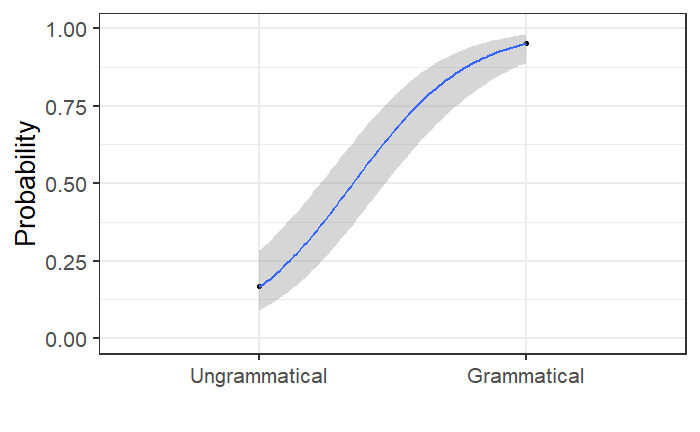

```r
grammatical <- grammatical %>%
  mutate(prob = predict(mdl.glm, type = "response"))
grammatical %>%
  ggplot(aes(x = as.numeric(grammaticality), y = prob)) +
  geom_point() +
  geom_smooth(method = "glm",
    method.args = list(family = "binomial"),
    se = T) + theme_bw(base_size = 20)+
    labs(y = "Probability", x = "")+
    coord_cartesian(ylim = c(0,1))+
    scale_x_discrete(limits = c("Ungrammatical", "Grammatical"))
```